# Reproducible Research: Peer Assessment 1

## Reproducible Research: Peer Assessment 1

### Introduction

This project satisfies the Johns Hopkins Reproducible Research course offered through Coursera, Project 1 requirements. It loads a data set, performs some processing, and produces some charts. The data involved concerns the number of steps taken as recorded by a Fitbit or other similar device.

### Loading and preprocessing the data

The data is in an unzipped file named “activity.csv”. If it has not already been loaded, it is loaded into memory.

```r
if (!exists("rawdata")){
    rawdata <- read.csv("activity.csv")
}
```

The data is then aggregated by date and a histogram produced displaying the data. This histogram is devided into 20 buckets, which was arbitrarily chosen.

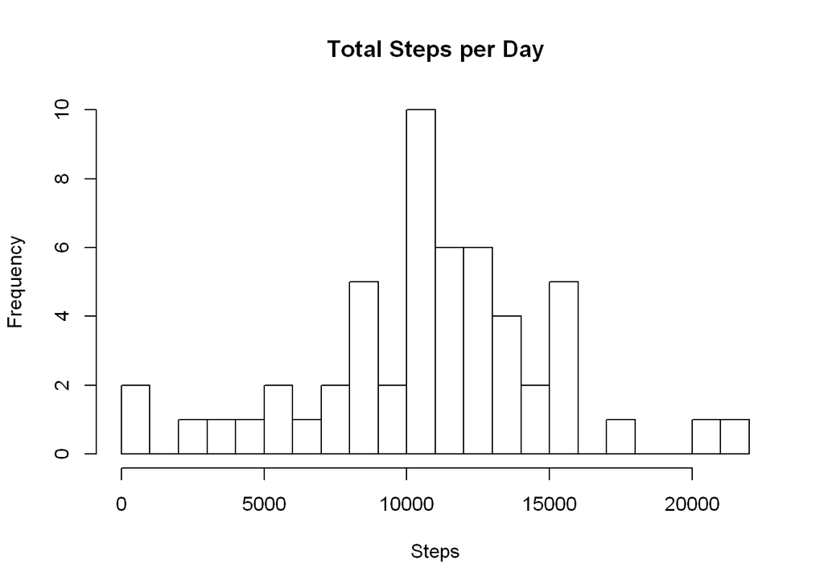

```r
data <- aggregate(steps ~ date, data=rawdata, sum, na.rm = TRUE)
hist(data$steps, breaks=20, main="Total Steps per Day", xlab="Steps", ylab="Frequency")
```

By looking at the histogram, we can make at fair estimate of what the median number of steps in a day will be. However, while looking at a histogram is a good way to get a quick feel for a data set, estimating visually is not always accurate enough.

### What is mean total number of steps taken per day?

```r
rawsteps_mean <- mean(rawdata$steps, na.rm=TRUE)
rawsteps_median <- median(rawdata$steps, na.rm=TRUE)
print(paste("The mean steps per day is: ", rawsteps_mean))
```

[output not shown]

```r
print(paste("The median steps per day is: ", rawsteps_median))
```

[output not shown]

### What is the average daily activity pattern?

To find the average daily activy pattern we aggregated the data on steps by the interval and took the mean. This was then plotted into a graph where the pattern is easily discernable. The maximum value, while easy to find on the graph, is found numerically and displayed.

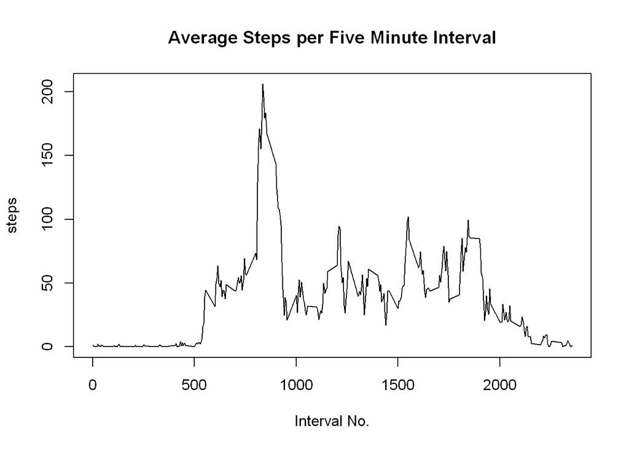

```r
stepsdata <- aggregate(steps ~ interval, data=rawdata, mean, na.rm=TRUE)
plot(stepsdata$interval, stepsdata$steps, type="l", main="Average Steps per Five Minute Interval",
     xlab="Interval No.", ylab="steps")
```

```r
maxsteps <- max(stepsdata$steps)
print(paste("The maximum number of steps in a five minute interval was: ", maxsteps))
```

```
## [1] "The maximum number of steps in a five minute interval was:  206.169811320755"
```

### Imputing missing values

There are numerous NAs in the initial data set.

```r
missingdata <- sum(is.na(rawdata$steps))
print(paste("There are", missingdata, "missing data points."))
```

```
## [1] "There are 2304 missing data points."
```

I chose to replace any NA value with the median value in the data set. This is not a terribly sophisticated method of replacing NA values but is sufficient to this task. The mean and median of this corrected data set are then calculated and displayed.

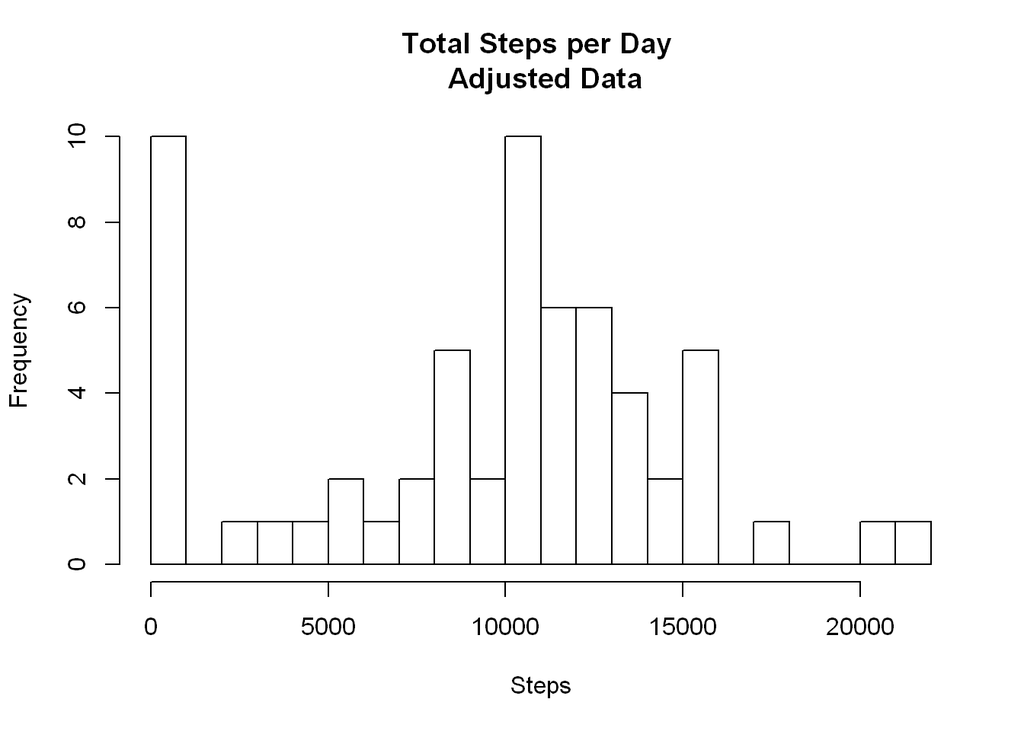

```r
betterdata <- rawdata
betterdata$steps[is.na(betterdata$steps)] <- median(rawdata$steps, na.rm=TRUE)
betterdataday <- aggregate(steps ~ date, data=betterdata, sum, na.rm=TRUE)
hist(betterdataday$steps, breaks=20, main="Total Steps per Day \n Adjusted Data",
     xlab="Steps", ylab="Frequency")
```

```r
bsteps_mean <- mean(betterdata$steps)
bsteps_median <- median(betterdata$steps)
print(paste("The mean is: ", bsteps_mean))
```

```
## [1] "The mean is:  32.4799635701275"
```

```r
print(paste("The median is: ", bsteps_median))
```

```
## [1] "The median is:  0"
```

These results for mean and median are not surprising as the median of the uncorrected set is 0, so replacing NAs with zeros unsurprisingly a) reduces the mean and b) has no impact on the median.

### Are there differences in activity patterns between weekdays and weekends?

[figure not shown]

```r
betterdata$date <- as.Date(betterdata$date)
betterdata$dayname <- weekdays(betterdata$date)
betterdata$weekend <- as.factor(ifelse(betterdata$dayname == "Saturday" |
                                 betterdata$dayname == "Sunday", "weekend", "weekday"))
library(lattice)
plotdata <- aggregate(steps ~ interval + weekend, betterdata, mean)
xyplot(steps ~ interval | factor(weekend), data=plotdata, aspect=1/3, type="l")
```